# Chapter 2 notes

Addison

4/17/2022

# Chapter 2 Time series graphics [[textbook link]](https://otexts.com/fpp3/graphics.html)

Quote: “Graphs enable many features of the data to be visualised, including patterns, unusual observations, changes over time, and relationships between variables”

Load required packages.

```r
library(fpp3)
library(readr)
```

## 2.1 `tsibble` objects [[section link]](https://otexts.com/fpp3/tsibbles.html)

Think of a time series as a list of numbers (measurements) along with info about the times they were recorded.

### The index variable [[subsection link]](https://otexts.com/fpp3/tsibbles.html#the-index-variable)

```r
# tsibble is used for temporal data
y <- tsibble(
  Year = 2015:2019,
  Observation = c(123, 39, 78, 52, 110),
  index = Year
)
y
```

```
## # A tsibble: 5 x 2 [1Y]
##    Year Observation
##   <int>       <dbl>
## 1  2015         123
## 2  2016          39
## 3  2017          78
## 4  2018          52
## 5  2019         110
```

```r
# Some example monthly observational data
mon <- c("2019 Jan", "2019 Feb", "2019 Mar","2019 Apr", "2019 May")
obs <- c(50, 23, 34, 30, 25)
z <- data.frame(Month = mon, Observations = obs)

# Creating a tsibble from a data frame of temporal data
z %>%
  # yearmonth, below, is an example of a time class function
  # other examples in Freq/Func table in section 2.1
  # from annual down to sub-daily.
  mutate(Month = yearmonth(Month)) %>%
  as_tsibble(index=Month)
```

```
## # A tsibble: 5 x 2 [1M]
##      Month Observations
##      <mth>        <dbl>
## 1 2019 Jan           50
## 2 2019 Feb           23
## 3 2019 Mar           34
## 4 2019 Apr           30
## 5 2019 May           25
```

### The key variables [[subsection link]](https://otexts.com/fpp3/tsibbles.html#the-key-variables)

```r
olympic_running
```

```
## # A tsibble: 312 x 4 [4Y]
## # Key:       Length, Sex [14]
##     Year Length Sex    Time
##    <int>  <int> <chr> <dbl>
##  1  1896    100 men    12
##  2  1900    100 men    11
##  3  1904    100 men    11
##  4  1908    100 men    10.8
##  5  1912    100 men    10.8
##  6  1916    100 men    NA
##  7  1920    100 men    10.8
##  8  1924    100 men    10.6
##  9  1928    100 men    10.8
## 10  1932    100 men    10.3
## # ... with 302 more rows
```

```r
# Show the categories of a variable
olympic_running %>% distinct(Sex)
```

```
## # A tibble: 2 x 1
##   Sex
##   <chr>
## 1 men
## 2 women
```

```r
# Show the distinct combinations of two variables.
# Section 2.1 states these two series uniquely identify
# each record.
olympic_running %>% distinct(Sex, Length)
```

```
## # A tibble: 14 x 2
##    Length Sex
##     <int> <chr>
##  1    100 men
##  2    100 women
##  3    200 men
##  4    200 women
##  5    400 men
##  6    400 women
##  7    800 men
##  8    800 women
##  9   1500 men
## 10   1500 women
## 11   5000 men
## 12   5000 women
## 13  10000 men
## 14  10000 women
```

### Working with `tsibble` objects [[subsection link]](https://otexts.com/fpp3/tsibbles.html#working-with-tsibble-objects)

Working with dataset `PBS`. Medicare Australia prescription data from July 1991 to June 2008. These are classified according to various concession types, and Anatomical Therapeutic Chemical (ATC) indexes.

```r
PBS
```

```
## # A tsibble: 67,596 x 9 [1M]
## # Key:       Concession, Type, ATC1, ATC2 [336]
##       Month Concession   Type      ATC1  ATC1_desc ATC2  ATC2_desc Scripts  Cost
##       <mth> <chr>        <chr>     <chr> <chr>     <chr> <chr>       <dbl> <dbl>
##  1 1991 Jul Concessional Co-payme~ A     Alimenta~ A01   STOMATOL~   18228 67877
##  2 1991 Aug Concessional Co-payme~ A     Alimenta~ A01   STOMATOL~   15327 57011
##  3 1991 Sep Concessional Co-payme~ A     Alimenta~ A01   STOMATOL~   14775 55020
##  4 1991 Oct Concessional Co-payme~ A     Alimenta~ A01   STOMATOL~   15380 57222
##  5 1991 Nov Concessional Co-payme~ A     Alimenta~ A01   STOMATOL~   14371 52120
##  6 1991 Dec Concessional Co-payme~ A     Alimenta~ A01   STOMATOL~   15028 54299
##  7 1992 Jan Concessional Co-payme~ A     Alimenta~ A01   STOMATOL~   11040 39753
##  8 1992 Feb Concessional Co-payme~ A     Alimenta~ A01   STOMATOL~   15165 54405
##  9 1992 Mar Concessional Co-payme~ A     Alimenta~ A01   STOMATOL~   16898 61108
## 10 1992 Apr Concessional Co-payme~ A     Alimenta~ A01   STOMATOL~   18141 65356
## # ... with 67,586 more rows
```

```r
# We're interested in the Cost time series
PBS %>%
  filter(ATC2 == "A10")
```

```
## # A tsibble: 816 x 9 [1M]
## # Key:       Concession, Type, ATC1, ATC2 [4]
##       Month Concession   Type     ATC1  ATC1_desc ATC2  ATC2_desc Scripts   Cost
##       <mth> <chr>        <chr>    <chr> <chr>     <chr> <chr>       <dbl>  <dbl>
##  1 1991 Jul Concessional Co-paym~ A     Alimenta~ A10   ANTIDIAB~   89733 2.09e6
##  2 1991 Aug Concessional Co-paym~ A     Alimenta~ A10   ANTIDIAB~   77101 1.80e6
##  3 1991 Sep Concessional Co-paym~ A     Alimenta~ A10   ANTIDIAB~   76255 1.78e6
##  4 1991 Oct Concessional Co-paym~ A     Alimenta~ A10   ANTIDIAB~   78681 1.85e6
##  5 1991 Nov Concessional Co-paym~ A     Alimenta~ A10   ANTIDIAB~   70554 1.69e6
##  6 1991 Dec Concessional Co-paym~ A     Alimenta~ A10   ANTIDIAB~   75814 1.84e6
##  7 1992 Jan Concessional Co-paym~ A     Alimenta~ A10   ANTIDIAB~   64186 1.56e6
##  8 1992 Feb Concessional Co-paym~ A     Alimenta~ A10   ANTIDIAB~   75899 1.73e6
##  9 1992 Mar Concessional Co-paym~ A     Alimenta~ A10   ANTIDIAB~   89445 2.05e6
## 10 1992 Apr Concessional Co-paym~ A     Alimenta~ A10   ANTIDIAB~   97315 2.23e6
## # ... with 806 more rows
```

```r
# We're interested in a few select columns
PBS %>%
  filter(ATC2 == "A10") %>%
  select(Month, Concession, Type, Cost)
```

```
## # A tsibble: 816 x 4 [1M]
## # Key:       Concession, Type [4]
##       Month Concession   Type           Cost
##       <mth> <chr>        <chr>         <dbl>
##  1 1991 Jul Concessional Co-payments 2092878
##  2 1991 Aug Concessional Co-payments 1795733
##  3 1991 Sep Concessional Co-payments 1777231
##  4 1991 Oct Concessional Co-payments 1848507
##  5 1991 Nov Concessional Co-payments 1686458
##  6 1991 Dec Concessional Co-payments 1843079
##  7 1992 Jan Concessional Co-payments 1564702
##  8 1992 Feb Concessional Co-payments 1732508
##  9 1992 Mar Concessional Co-payments 2046102
## 10 1992 Apr Concessional Co-payments 2225977
## # ... with 806 more rows
```

```r
# We want to see the total cost per month
# regardless of Concession or Type
PBS %>%
  filter(ATC2 == "A10") %>%
  select(Month, Concession, Type, Cost) %>%
  summarise(TotalC = sum(Cost))
```

```
## # A tsibble: 204 x 2 [1M]
##       Month  TotalC
##       <mth>   <dbl>
##  1 1991 Jul 3526591
##  2 1991 Aug 3180891
##  3 1991 Sep 3252221
##  4 1991 Oct 3611003
##  5 1991 Nov 3565869
##  6 1991 Dec 4306371
##  7 1992 Jan 5088335
##  8 1992 Feb 2814520
##  9 1992 Mar 2985811
## 10 1992 Apr 3204780
## # ... with 194 more rows
```

```r
# change the units from dollars to millions of dollars
# and save result to new variable.
PBS %>%
  filter(ATC2 == "A10") %>%
  select(Month, Concession, Type, Cost) %>%
  summarise(TotalC = sum(Cost)) %>%
  mutate(Cost = TotalC / 1e6) -> a10

a10
```

```
## # A tsibble: 204 x 3 [1M]
##       Month  TotalC  Cost
##       <mth>   <dbl> <dbl>
##  1 1991 Jul 3526591  3.53
##  2 1991 Aug 3180891  3.18
##  3 1991 Sep 3252221  3.25
##  4 1991 Oct 3611003  3.61
##  5 1991 Nov 3565869  3.57
##  6 1991 Dec 4306371  4.31
##  7 1992 Jan 5088335  5.09
##  8 1992 Feb 2814520  2.81
##  9 1992 Mar 2985811  2.99
## 10 1992 Apr 3204780  3.20
## # ... with 194 more rows
```

### Read a csv file and conver to a tsibble [[subsection link]](https://otexts.com/fpp3/tsibbles.html#read-a-csv-file-and-convert-to-a-tsibble)

Commonly one reads in csv data, and then identifies the index and key variables.

```r
prison <- readr::read_csv("remote_data/prison_population.csv")
prison <- prison %>%
  mutate(Quarter = yearquarter(Date)) %>%
  # select everything except the Date column
  select(-Date) %>%
  as_tsibble(
    key = c(State, Gender, Legal, Indigenous),
    index = Quarter
  )

prison
```

```
## # A tsibble: 3,072 x 6 [1Q]
## # Key:       State, Gender, Legal, Indigenous [64]
##    State Gender Legal    Indigenous Count Quarter
##    <chr> <chr>  <chr>    <chr>      <dbl>   <qtr>
##  1 ACT   Female Remanded ATSI           0 2005 Q1
##  2 ACT   Female Remanded ATSI           1 2005 Q2
##  3 ACT   Female Remanded ATSI           0 2005 Q3
##  4 ACT   Female Remanded ATSI           0 2005 Q4
##  5 ACT   Female Remanded ATSI           1 2006 Q1
##  6 ACT   Female Remanded ATSI           1 2006 Q2
##  7 ACT   Female Remanded ATSI           1 2006 Q3
##  8 ACT   Female Remanded ATSI           0 2006 Q4
##  9 ACT   Female Remanded ATSI           0 2007 Q1
## 10 ACT   Female Remanded ATSI           1 2007 Q2
## # ... with 3,062 more rows
```

Book states: “for a tsibble to be valid, it requires a unique index for each combination of keys.” Therefore, we get an error with the following:

```r
tryCatch(
  expr = data.frame(
    Year = c(1990,1990,1990,1990),
    key1 = c("3","3","3","3"),
    key2 = c("4","5","5","6"),
    m  = c(1,2,3,4)
  ) %>% as_tsibble(index = Year, key = c(key1, key2)),
  error = function(x) {
    x
  }
)
```

```
## <error/rlang_error>
## Error in `validate_tsibble()`:
## ! A valid tsibble must have distinct rows identified by key and index.
## i Please use `duplicates()` to check the duplicated rows.
## ---
## Backtrace:
##  1. base::tryCatch(...)
##  7. tsibble:::as_tsibble.data.frame(...)
##  8. tsibble::build_tsibble(...)
##  9. tsibble:::validate_tsibble(...)
```

```r
print("tryCatch worked as expected: printed error and execution continued.")
```

```
## [1] "tryCatch worked as expected: printed error and execution continued."
```

### The seasonal period [[subsection link]](https://otexts.com/fpp3/tsibbles.html#the-seasonal-period)

Contains a useful table containing numbers of time units in different periods.

## 2.2 Time plots

“For time series data, the obvious graph to start with is a time plot. That is, the observations are plotted against the time of observation, with consecutive observations joined by straight lines.”

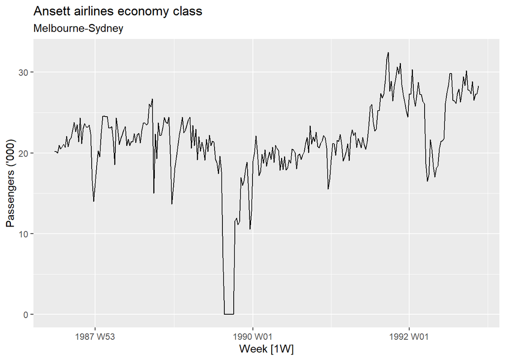

```r
melsyd_economy <- ansett %>%
  filter(Airports == "MEL-SYD", Class == "Economy") %>%
  mutate(Passengers = Passengers / 1000)

# Automatically select a plot given the data passed in
autoplot(melsyd_economy, Passengers) +
  labs(title = "Ansett airlines economy class",
       subtitle = "Melbourne-Sydney",
       y = "Passengers ('000)")
```

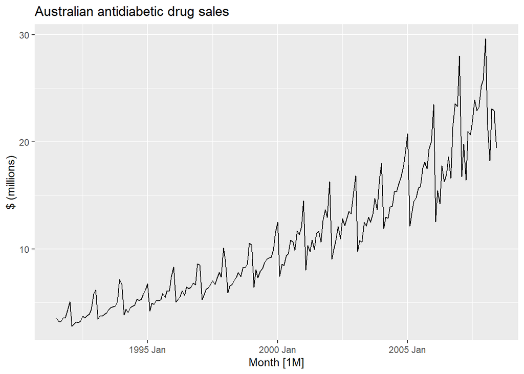

```r
# relies on a10 data from section 2.1
autoplot(a10, Cost) +
  labs(y = "$ (millions)",
       title = "Australian antidiabetic drug sales")
```

## 2.3 Time series patterns

More careful definitions of “trend” and “seasonal” would be useful.

### Trend

Long period of overall increase or decrease. There may be seasonal ups and downs, but overall there is a general direction. Does not have to be linear.

### Seasonal

Seasonal patterns are where there is a clear effect that lines up with some time period like yearly or weekly. Seasonality is always associated with a fixed time period length.

### Cyclic

Like seasonal, but not associated with a necessarily fixed time period length. Often associated with economic events, or what “business cycles.” The duration is typically at least 2 years.

Cyclic and seasonal often confused for one another, but in actuality they are quite different. Figure 2.3 shows different combinations of these components. [[Link to figure]](https://otexts.com/fpp3/tspatterns.html#fig:fourexamples).

1. Top left: No apparent trend. Strong yearly seasonal pattern. Apparent 6-10 year cycle.
2. Top right: Clear downward trend. No clear seasonality. Book mentions more data might reveal the trend is part of a cycle. *I think I can see a potential cycle on the order of 25 years.*
3. Bottom left: Clear upward trend. Apparent strong seasonality. No evidence of cyclic component.
4. Bottom right: No clear trend, seasonality, or cyclic behavior. Apparently no strong patterns that would help develop a forecasting model.

## 2.4 Seasonal Plots

Like time plot except each season broken out into separate series for the plot.

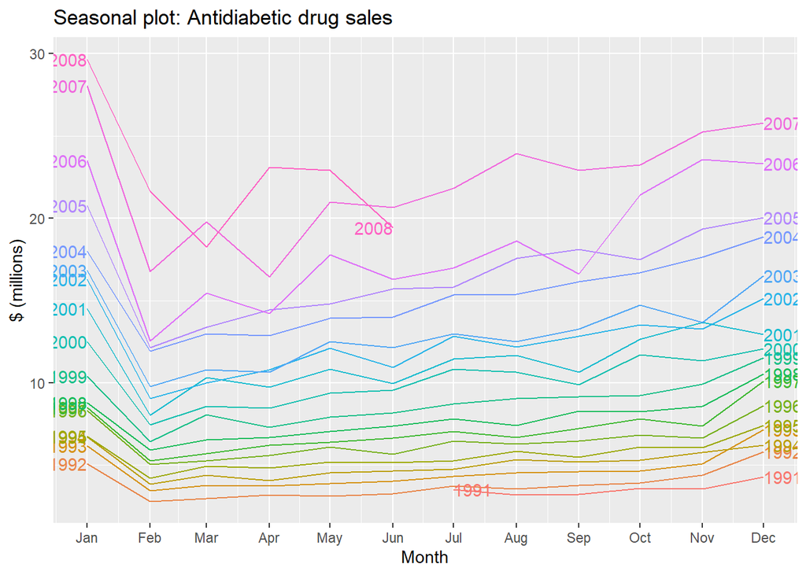

```r
a10 %>%
  gg_season(Cost, labels = "both") +
  labs(y = "$ (millions)",
       title = "Seasonal plot: Antidiabetic drug sales")
```

Aspects of seasonal plots: - Can see seasonal patterns clearly - Can see deviations between seasons more easily - Useful, for example, in seeing years in which patterns change

In the above plot - you can see a repeating bump in sales recorded in January each year - you can see dip in March 2008 sales unlike other years - the dip in June 2008 probably due to sales data not completely collected yet for that month.

### Multiple seasonal periods [[subsection link]](https://otexts.com/fpp3/seasonal-plots.html#multiple-seasonal-periods)

The seasonal plot function, `gg_seasonal`, allows you to plot different period lengths with the `period` argument.

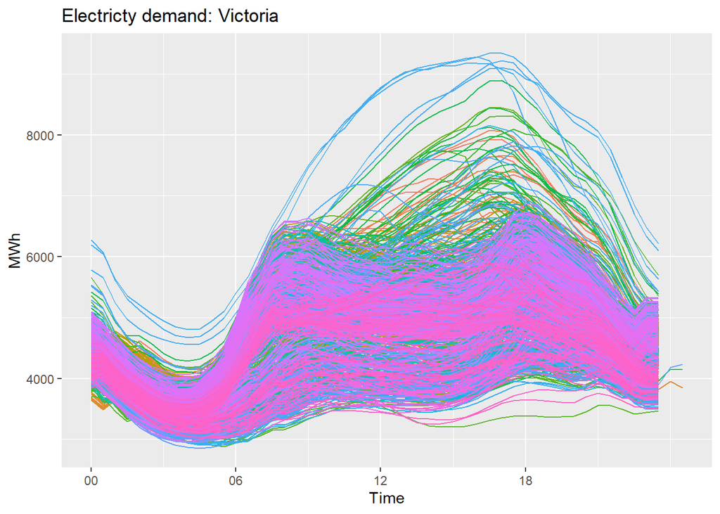

```r
vic_elec %>%
  gg_season(Demand, period = "day") +
  theme(legend.position = "none") +
  labs(y = "MWh", title = "Electricty demand: Victoria")
```

Above, you can see 3 lines with 25 hours, which correspond to uncorrected daylight savings times.

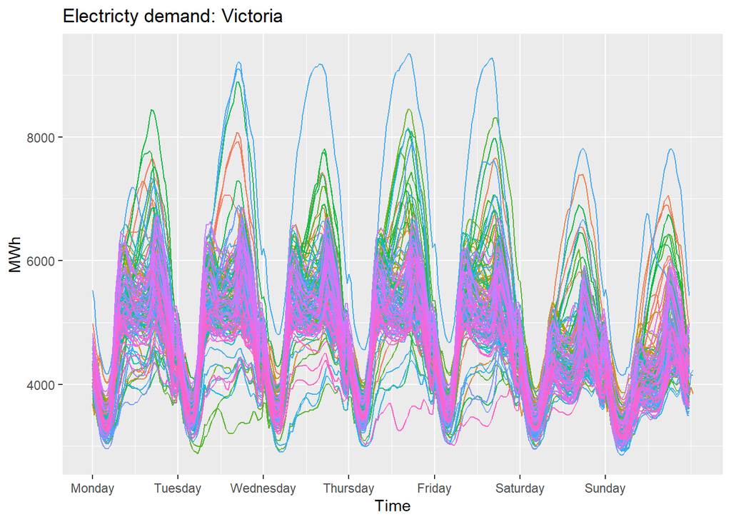

```r
vic_elec %>%
  gg_season(Demand, period = "week") +
  theme(legend.position = "none") +
  labs(y = "MWh", title = "Electricty demand: Victoria")
```

Above you can see weekly seasonal patterns.

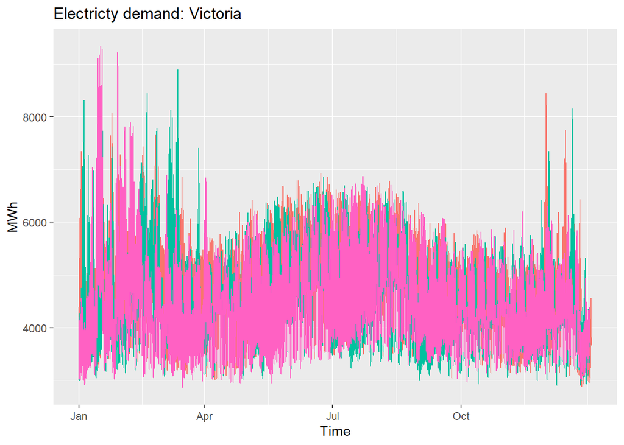

```r
vic_elec %>%
  gg_season(Demand, period = "year") +
  theme(legend.position = "none") +
  labs(y = "MWh", title = "Electricty demand: Victoria")
```

Here you can see the yearly seasonal patterns.

## 2.5 Seasonal subseries plots [[subsection link]](https://otexts.com/fpp3/subseries.html#subseries)

You can also create subplots, one per month, with the domain over the different years.

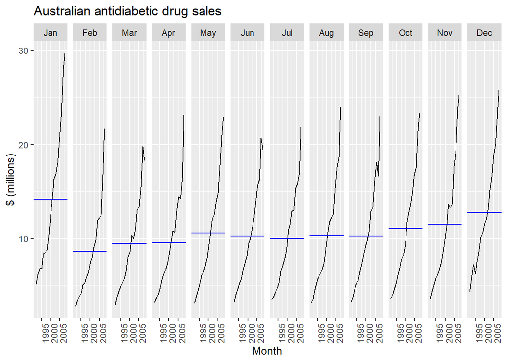

```r
a10 %>%
  gg_subseries(Cost) +
  labs(y = '$ (millions)',
       title = 'Australian antidiabetic drug sales')
```

The book mentions the blue line indicating the seasonality, but I don’t find it particularly easy to conclude that from looking at this plot. The book goes on to say the plot isn’t particularly revealing, with which I agree. I am curious what it would look like if there was a subplot per year, and the domain going over that year.

I tried to change the domain with the following, but it didn’t do what I was aiming for.

```r
# This does not do the thing. Anyone know how?

# a10 %>%
#   gg_subseries(Cost) +
#   labs(y = '$ (millions)',
#        title = 'Australian antidiabetic drug sales',
#        period = 'year')
```

```r
head(tourism)
```

```
## # A tsibble: 6 x 5 [1Q]
## # Key:       Region, State, Purpose [1]
##   Quarter Region   State           Purpose  Trips
##     <qtr> <chr>    <chr>           <chr>    <dbl>
## 1 1998 Q1 Adelaide South Australia Business  135.
## 2 1998 Q2 Adelaide South Australia Business  110.
## 3 1998 Q3 Adelaide South Australia Business  166.
## 4 1998 Q4 Adelaide South Australia Business  127.
## 5 1999 Q1 Adelaide South Australia Business  137.
## 6 1999 Q2 Adelaide South Australia Business  200.
```

```r
holidays <- tourism %>%
  filter(Purpose == 'Holiday') %>%
  group_by(State) %>%
  summarise(Trips = sum(Trips))

head(holidays)
```

```
## # A tsibble: 6 x 3 [1Q]
## # Key:       State [1]
##   State Quarter Trips
##   <chr>   <qtr> <dbl>
## 1 ACT   1998 Q1  196.
## 2 ACT   1998 Q2  127.
## 3 ACT   1998 Q3  111.
## 4 ACT   1998 Q4  170.
## 5 ACT   1999 Q1  108.
## 6 ACT   1999 Q2  125.
```

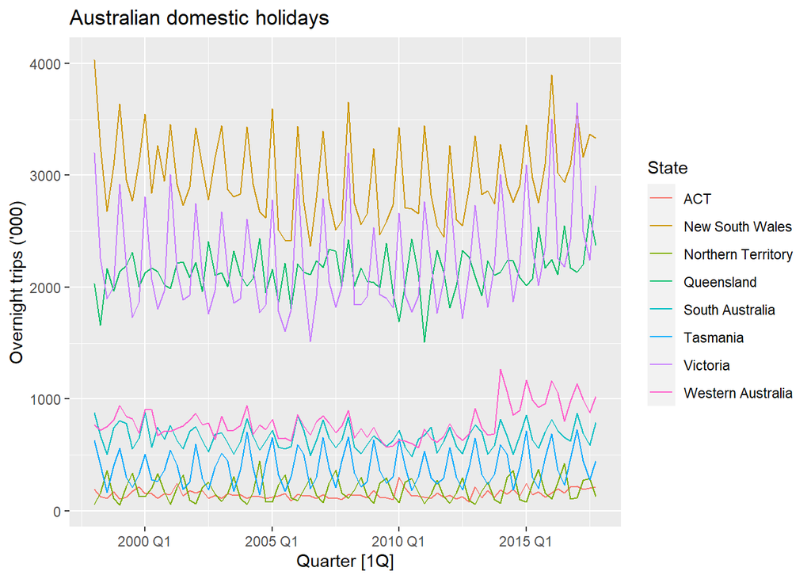

```r
autoplot(holidays, Trips) +
  labs(y = "Overnight trips ('000)",
       title = 'Australian domestic holidays')
```

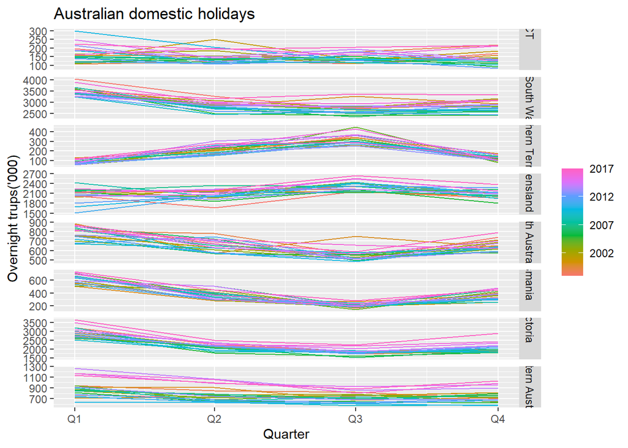

```r
gg_season(holidays, Trips) +
  labs(y = "Overnight trups('000)",
       title = "Australian domestic holidays")
```

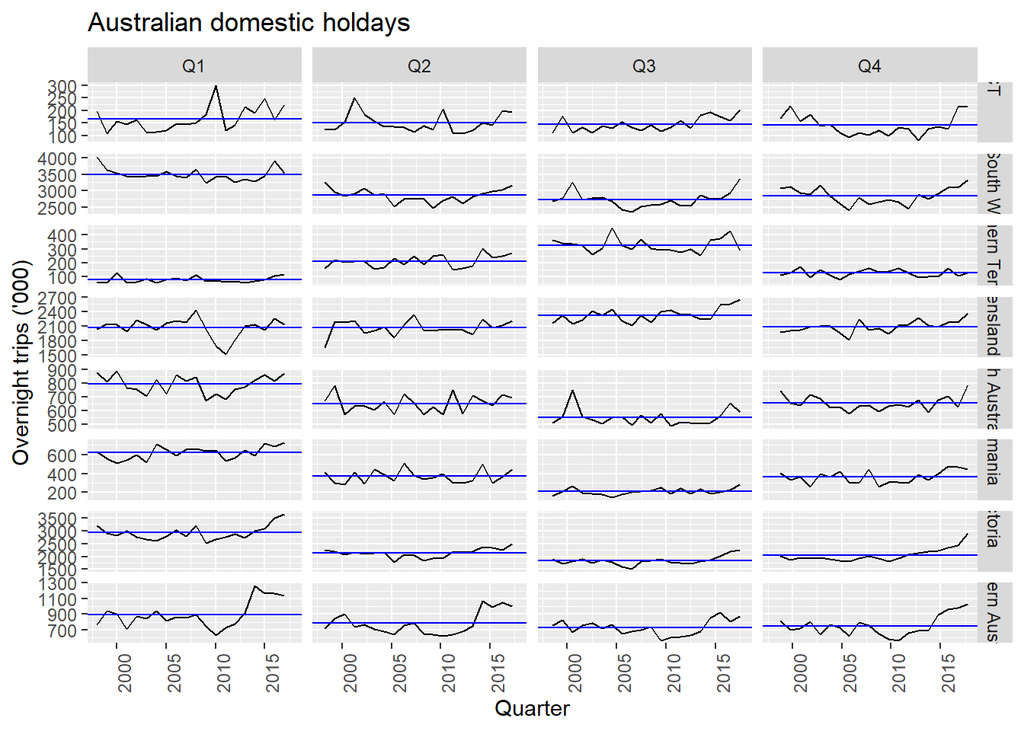

```r
holidays %>%
  gg_subseries(Trips) +
  labs(y = "Overnight trips ('000)",
       title = "Australian domestic holdays")
```

Above, you can see most of the regions have seen an increase over the mean in the past few years.

## Scatterplots [[section link]](https://otexts.com/fpp3/scatterplots.html)

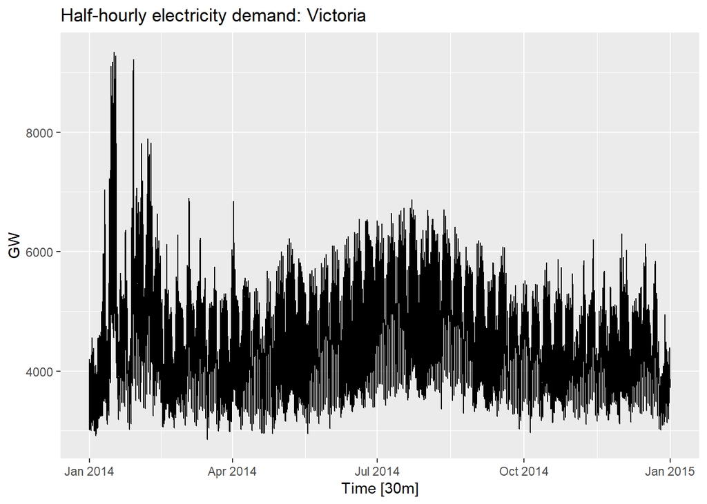

```r
vic_elec %>%
  filter(year(Time) == 2014) %>%
  autoplot(Demand) +
  labs(y = "GW",
       title = "Half-hourly electricity demand: Victoria")
```

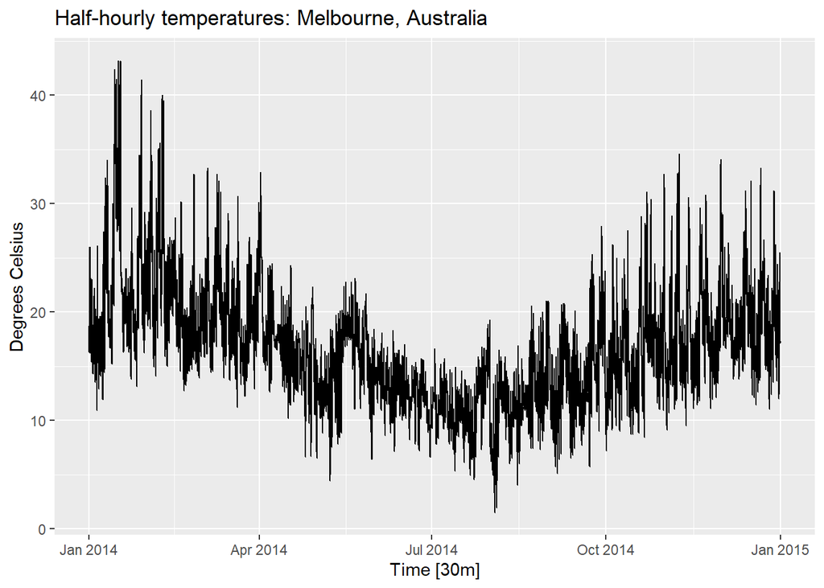

```r
vic_elec %>%
  filter(year(Time) == 2014) %>%
  autoplot(Temperature) +
  labs(
    y = "Degrees Celsius",
    title = "Half-hourly temperatures: Melbourne, Australia"
  )
```

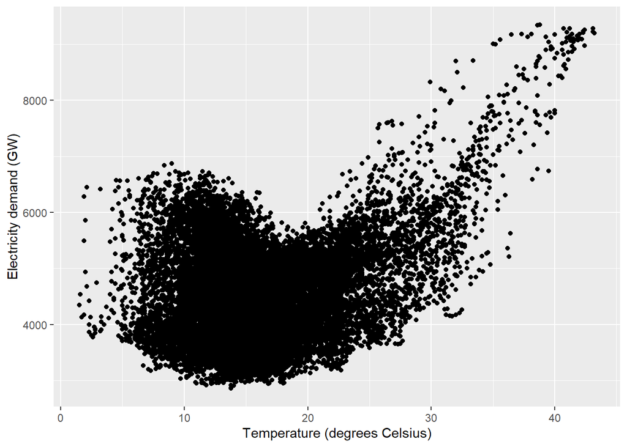

```r
vic_elec %>%
  filter(year(Time) == 2014) %>%
  ggplot(aes(x = Temperature, y = Demand)) +
  geom_point() +
  labs(x = "Temperature (degrees Celsius)",
       y = "Electricity demand (GW)")
```

Figures 2.14 and 2.15 display correlations between various variables. Wikipedia article on Correlation: [[wikipedia]](https://en.wikipedia.org/wiki/Correlation).

### Scatterplot matrices [[subsection link]](https://otexts.com/fpp3/scatterplots.html#scatterplot-matrices)

```r
visitors <- tourism %>%
  group_by(State) %>%
  summarise(Trips = sum(Trips))
head(visitors)
```

```
## # A tsibble: 6 x 3 [1Q]
## # Key:       State [1]
##   State Quarter Trips
##   <chr>   <qtr> <dbl>
## 1 ACT   1998 Q1  551.
## 2 ACT   1998 Q2  416.
## 3 ACT   1998 Q3  436.
## 4 ACT   1998 Q4  450.
## 5 ACT   1999 Q1  379.
## 6 ACT   1999 Q2  558.
```

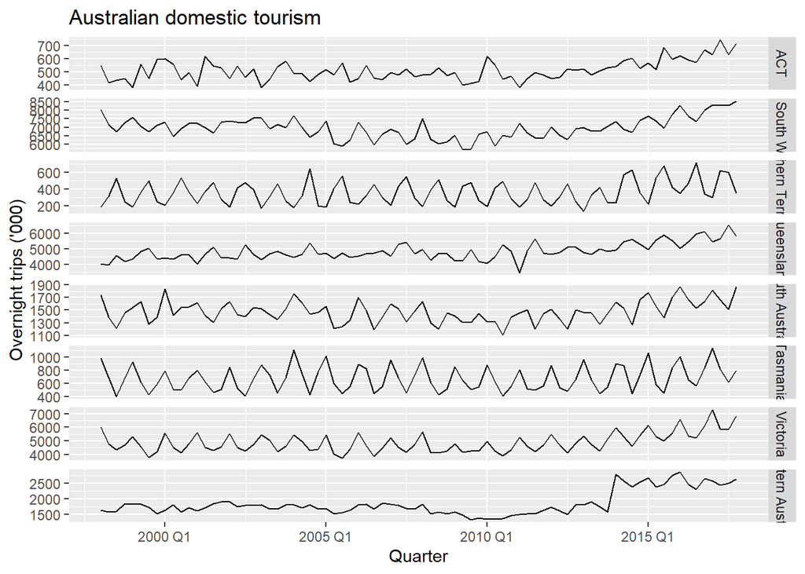

```r
visitors %>%
  ggplot(aes(x = Quarter, y = Trips)) +
  geom_line() +
  facet_grid(vars(State), scales = "free_y") +
  labs(title = "Australian domestic tourism",
       y= "Overnight trips ('000)")
```

```r
library(GGally)
```

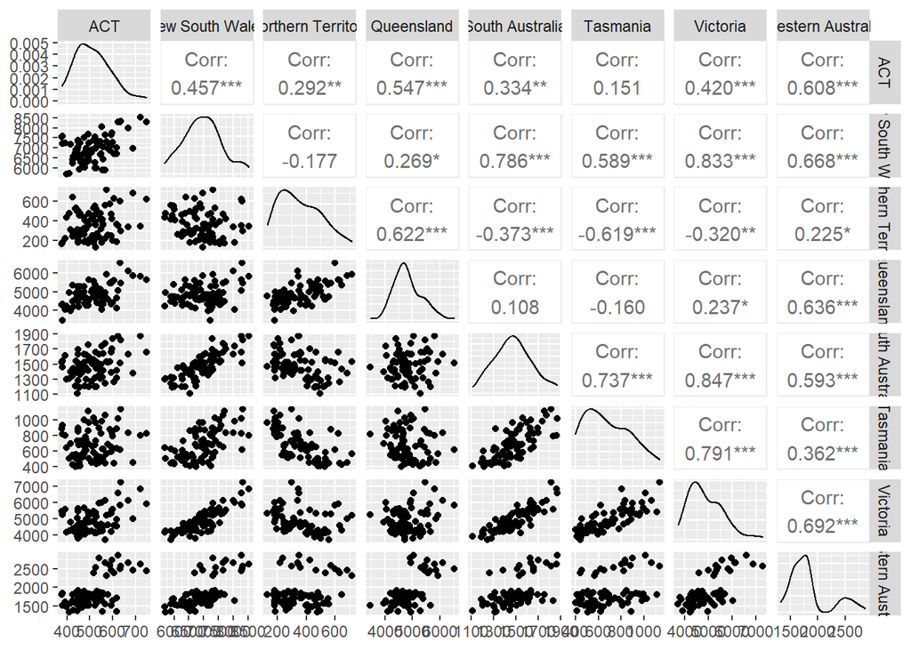

```r
visitors %>%
  pivot_wider(values_from=Trips, names_from=State) %>%
  GGally::ggpairs(columns = 2:9)
```

## 2.7 Lag plots [[section link]](https://otexts.com/fpp3/lag-plots.html)

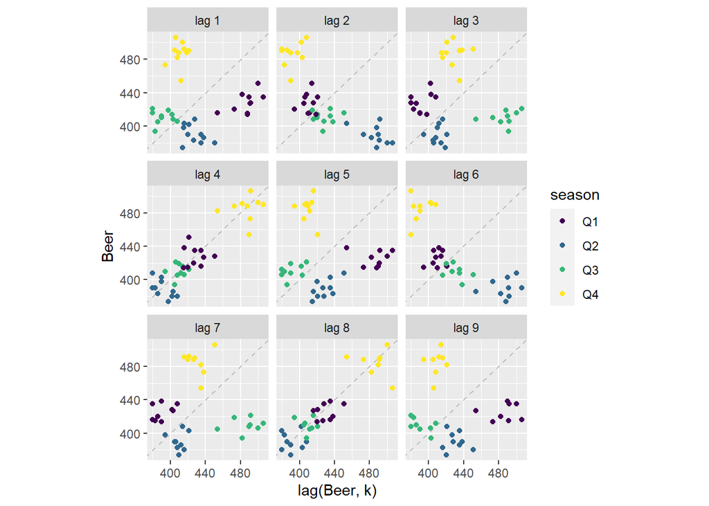

```r
recent_production <- aus_production %>%
  filter(year(Quarter) >= 2000)
recent_production %>%
  gg_lag(Beer, geom = "point") +
  labs(x = "lag(Beer, k)")
```

Book quote: “Here the colours indicate the quarter of the variable on the vertical axis. The relationship is strongly positive at lags 4 and 8”

Intuitively, I think this is because when you lag by multiples of four, you are kind of seeing the quarter-seasonal repetition. Is that how you all interpreted it?

## Autocorrelation [[subsection link]](https://otexts.com/fpp3/acf.html)

Measures the relationship between lagged values of a time series. Formula in book looks similar to correlation but with the second variable being some different year, in this case.

```r
head(recent_production)
```

```
## # A tsibble: 6 x 7 [1Q]
##   Quarter  Beer Tobacco Bricks Cement Electricity   Gas
##     <qtr> <dbl>   <dbl>  <dbl>  <dbl>       <dbl> <dbl>
## 1 2000 Q1   421    5169    416   1835       49320   164
## 2 2000 Q2   402    4860    447   2070       50670   199
## 3 2000 Q3   414    5185    421   1898       52623   213
## 4 2000 Q4   500    4763    379   1652       49350   173
## 5 2001 Q1   451    4217    304   1554       51658   177
## 6 2001 Q2   380    4959    337   1717       51103   205
```

```r
recent_production %>% ACF(Beer, lag_max)
```

```
## # A tsibble: 16 x 2 [1Q]
##      lag      acf
##    <lag>    <dbl>
##  1    1Q -0.0530
##  2    2Q -0.758
##  3    3Q -0.0262
##  4    4Q  0.802
##  5    5Q -0.0775
##  6    6Q -0.657
##  7    7Q  0.00119
##  8    8Q  0.707
##  9    9Q -0.0888
## 10   10Q -0.588
## 11   11Q  0.0241
## 12   12Q  0.632
## 13   13Q -0.0660
## 14   14Q -0.505
## 15   15Q -0.00891
## 16   16Q  0.498
```

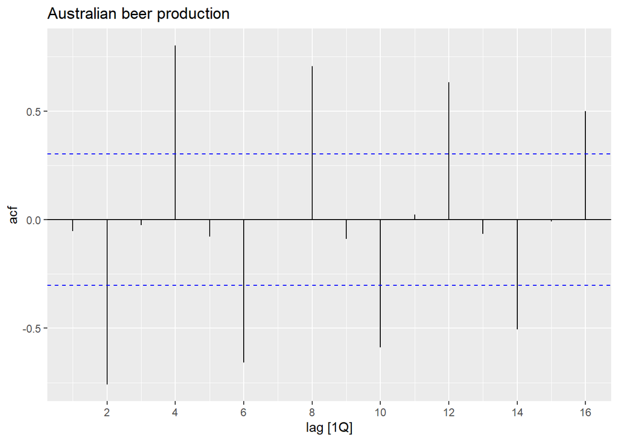

```r
recent_production %>%
  ACF(Beer) %>%
  autoplot() + labs(title = "Australian beer production")
```

I believe the optima in the coefficients are related to the four-quarter repetitions in the data.

### Trend and seasonality in ACF plots [[subsection link]](https://otexts.com/fpp3/acf.html#trend-and-seasonality-in-acf-plots)

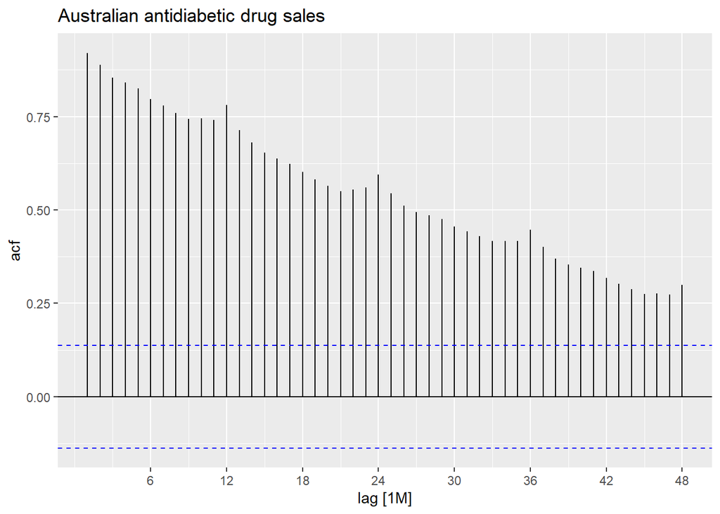

```r
a10 %>%
  ACF(Cost, lag_max = 48) %>%
  autoplot() +
  labs(title="Australian antidiabetic drug sales")
```

For trends, autocorrelation decreases for increasing lags since the more recent lags are closer in value that further in the past.

For seasonal data, autocorrelation coefficients peak at the seasonal periods.

For trending and seasonal data, the autocorrelation shows both of these relationships.

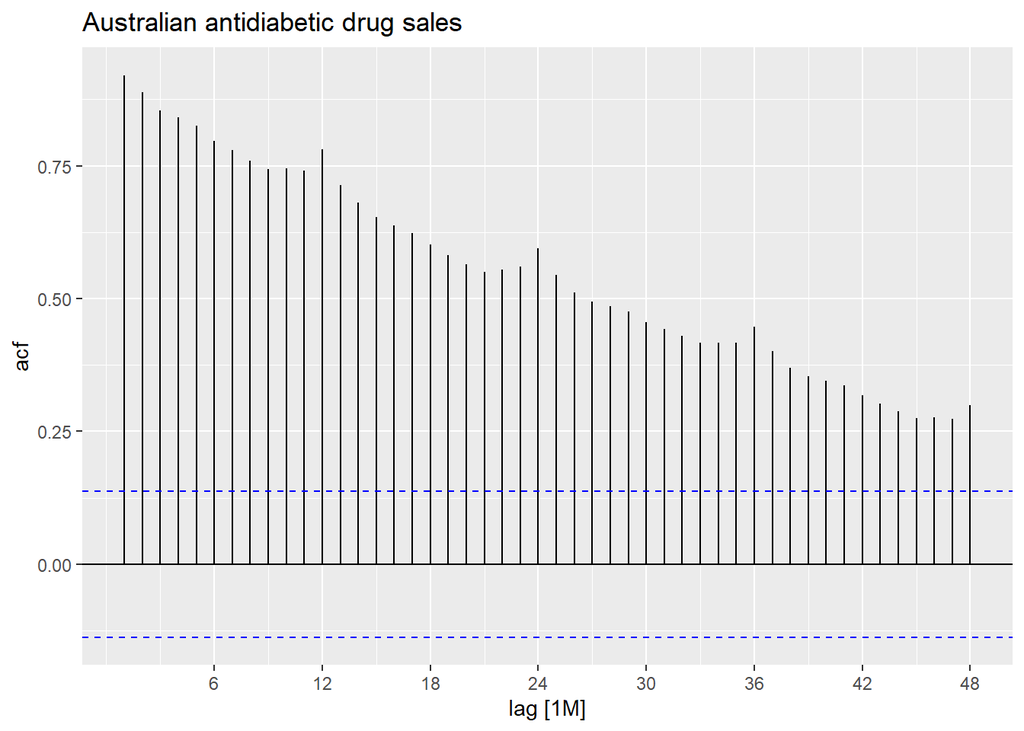

```r
a10 %>%
  ACF(Cost, lag_max = 48) %>%
  autoplot() +
  labs(title="Australian antidiabetic drug sales")
```

## 2.9 White noise [[section link]](https://otexts.com/fpp3/wn.html)

Lack of autocorrelation called “white noise.”

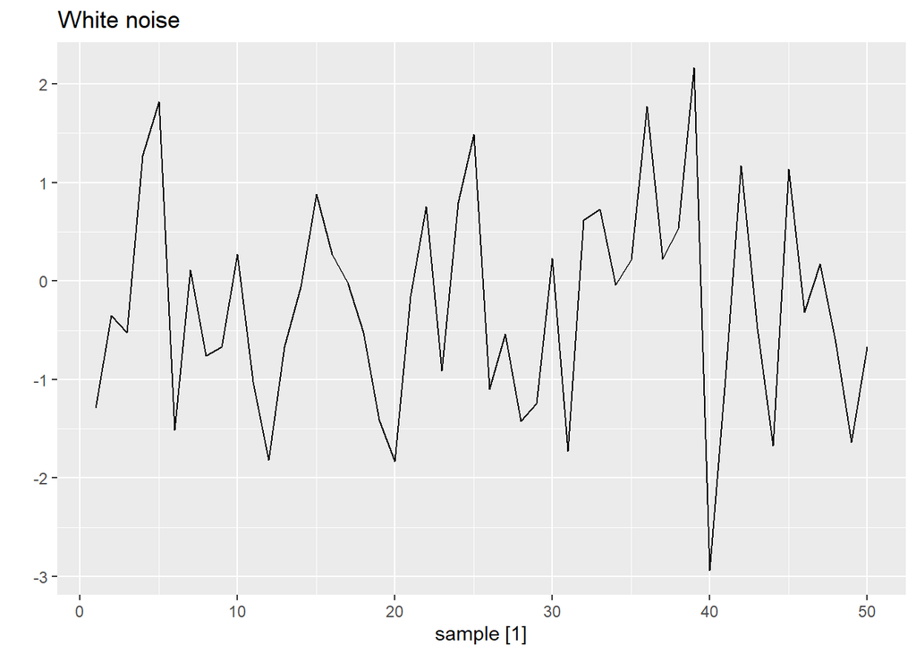

```r
set.seed(30)
y <- tsibble(sample = 1:50, wn = rnorm(50), index = sample)
y %>% autoplot(wn) + labs(title = "White noise", y = "")
```

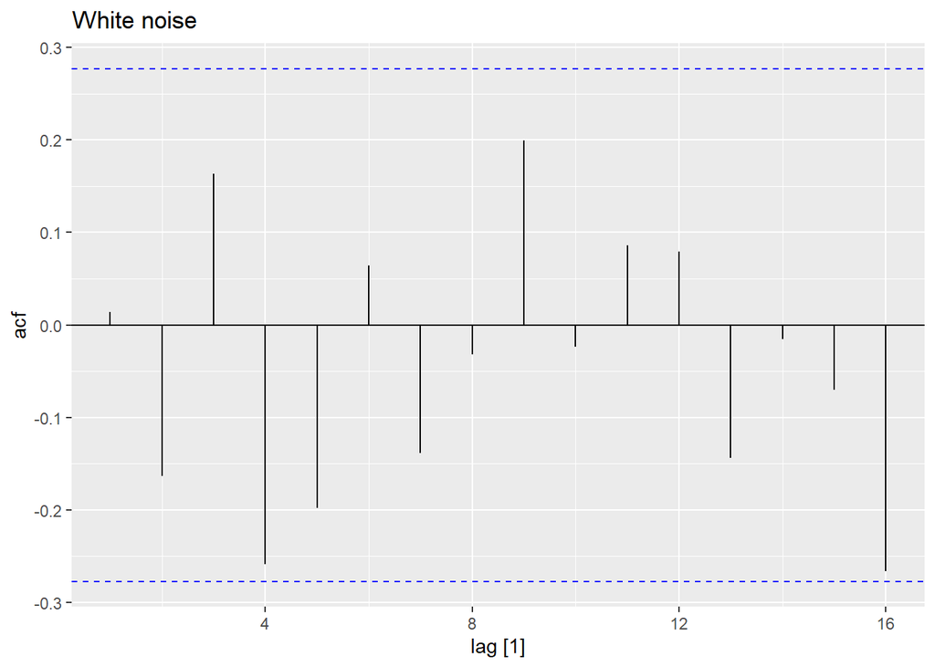

```r
y %>%
  ACF(wn) %>%
  autoplot() + labs(title = "White noise")
```

Above, you can see there’s no clear pattern in the autocorrelation coefficients, and the coefficients are rather close to zero.